# Regression Analysis Case Study - Hald Cement Dataset

G Radhesyam

19 March 2022

## HALD CEMENT Dataset

- The response variable Y is the heat evolved in a cement mix.
- The four explanatory variables are ingredients of the mix,
  - X1:Tricalcium aluminate
  - X2:Tricalcium silicate,
  - X3:Tetracalcium alumino ferrite
  - X4:Dicalcium silicate.

## HALD CEMENT Dataset

```
## # A tibble: 6 x 5
##       Y    X1    X2    X3    X4
##   <dbl> <dbl> <dbl> <dbl> <dbl>
## 1  78.5     7    26     6    60
## 2  74.3     1    29    15    52
## 3 104.     11    56     8    20
## 4  87.6    11    31     8    47
## 5  95.9     7    52     6    33
## 6 109.     11    55     9    22
```

```
## spec_tbl_df [13 x 5] (S3: spec_tbl_df/tbl_df/tbl/data.frame)
##  $ Y : num [1:13] 78.5 74.3 104.3 87.6 95.9 ...
##  $ X1: num [1:13] 7 1 11 11 7 11 3 1 2 21 ...
##  $ X2: num [1:13] 26 29 56 31 52 55 71 31 54 47 ...
##  $ X3: num [1:13] 6 15 8 8 6 9 17 22 18 4 ...
##  $ X4: num [1:13] 60 52 20 47 33 22 6 44 22 26 ...
##  - attr(*, "spec")=
##   .. cols(
##   ..   Y = col_double(),
##   ..   X1 = col_double(),
##   ..   X2 = col_double(),
##   ..   X3 = col_double(),
##   ..   X4 = col_double()
##   .. )
##  - attr(*, "problems")=<externalptr>
```

## HALD CEMENT - FINAL MODEL SUMMARY

- Model : X1+X2
  - Y = 52.5773 + (1.4683) X1 + ( 0.6623) X2
  - All Regression assumptions met.
- Normality test
  - Shapiro-wilks Test - Distribution is Normal
- W = 0.90219, p-value = 0.1433
- Anderson-Darling test - Distribution is normal
- A = 0.61361, p-value = 0.08628
- Equal Variance Test
  - studentized Breusch-Pagan test
  - BP = 0.16688, df = 2, p-value = 0.9199
  - H0 : Variances are equal

## HALD CEMENT - FINAL MODEL SUMMARY (Contd…)

```
  * Independence/Auto Correllation Test (Durbin-Watson (D-W) test )
     - H0 : Auto correlation is zero
```

| lag | Autocorrelation | D-W Statistic | p-value |
| --- | --- | --- | --- |
| 1 | -0.05450402 | 1.92164 | 0.892 |

- Linearity test
  - Box-Tidwell - H0 : No Transformation needed
  - Box-Tidwell test (Y,X1)
  - MLE of lambda Score Statistic (z) Pr(>|z|)

  - ```
      0.23145             -0.7366   0.4614
    ```

  - Box-Tidwell test ( Y,X2)
  - MLE of lambda Score Statistic (z) Pr(>|z|)
  - -0.71695 -1.35 0.177

## HALD CEMENT - MODEL ANALYSIS and DETAILS

- An F statistic is a value you get when you run an ANOVA test or a regression analysis to find out if the means between two populations are significantly different.
- It’s similar to a T statistic from a T-Test;
- A T-test will tell you if a single variable is statistically significant and
- an F test will tell you if a group of variables are jointly significant.
- https://www.statisticshowto.com/probability-and-statistics/f-statistic-value-test/
- Regression NULL Hypothesis: All of the regression coefficients are equal to zero
- Tip: P-value is High ,NUll will Fly

- ```
   P-value is low, NULL will blow
  ```

- T-Test in Regression
- https://www.statology.org/t-test-linear-regression/

```
##
## Call:
## lm(formula = haldcement$Y ~ ., data = haldcement)
##
## Residuals:
##     Min      1Q  Median      3Q     Max
## -3.1750 -1.6709  0.2508  1.3783  3.9254
##
## Coefficients:
##             Estimate Std. Error t value Pr(>|t|)
## (Intercept)  62.4054    70.0710   0.891   0.3991
## X1            1.5511     0.7448   2.083   0.0708 .
## X2            0.5102     0.7238   0.705   0.5009
## X3            0.1019     0.7547   0.135   0.8959
## X4           -0.1441     0.7091  -0.203   0.8441
## ---
## Signif. codes:  0 '***' 0.001 '**' 0.01 '*' 0.05 '.' 0.1 ' ' 1
##
## Residual standard error: 2.446 on 8 degrees of freedom
## Multiple R-squared:  0.9824, Adjusted R-squared:  0.9736
## F-statistic: 111.5 on 4 and 8 DF,  p-value: 4.756e-07
```

## HALD CEMENT - Scatter plot

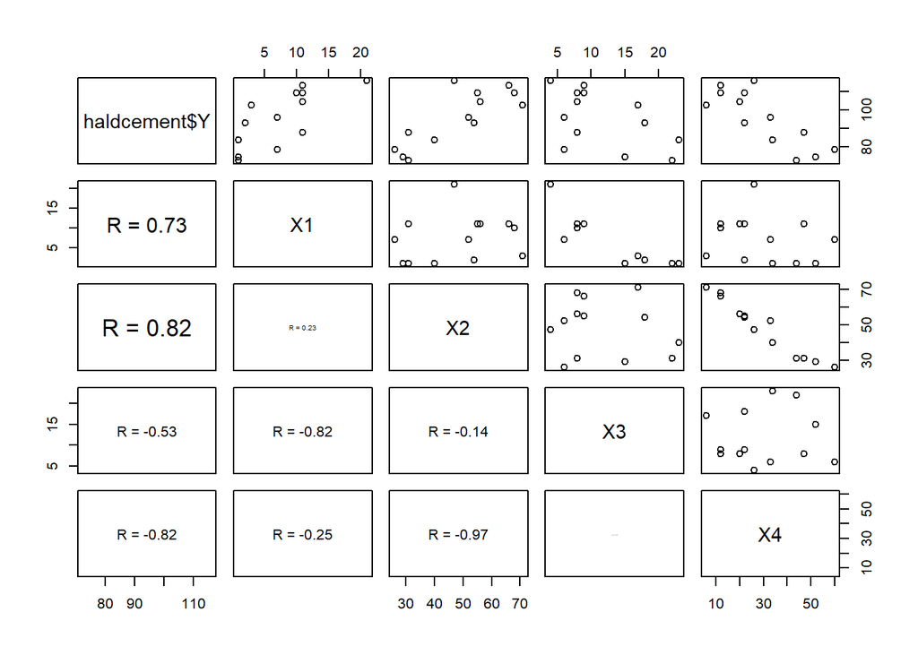

- https://ggobi.github.io/ggally/reference/ggpairs.html

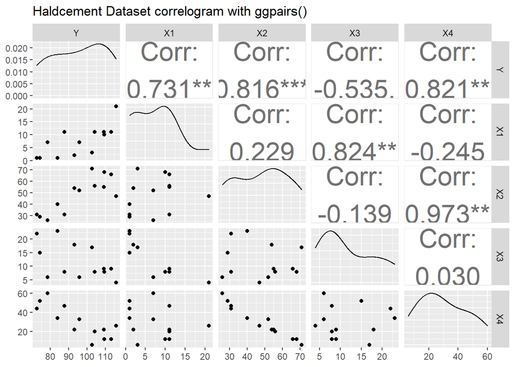

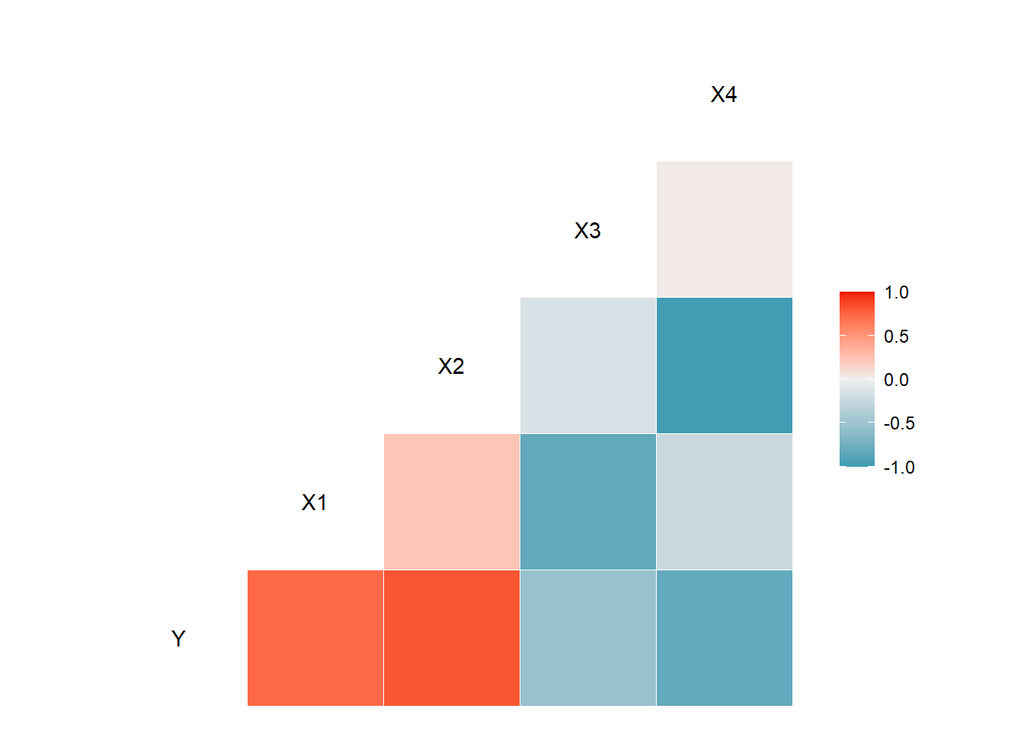

## HALD CEMENT - Influence points

- https://www.rdocumentation.org/packages/stats/versions/3.6.2/topics/influence.measures
- influence.measures: Regression Deletion Diagnostics
- https://rpubs.com/mpfoley73/501093

```
##  1  3  5 10
##  1  3  5 10
```

```
## Potentially influential observations of
##   lm(formula = haldcement$Y ~ ., data = haldcement) :
##
##    dfb.1_  dfb.X1  dfb.X2  dfb.X3  dfb.X4  dffit cov.r   cook.d hat
## 1   0.00    0.00    0.00    0.00    0.00    0.00  4.34_*  0.00   0.55
## 3  -1.10_*  1.03_*  1.08_*  1.08_*  1.10_* -1.24  2.19    0.30   0.58
## 5  -0.02    0.00    0.02    0.00    0.02    0.09  3.00_*  0.00   0.36
## 10 -0.05    0.12    0.04    0.08    0.05    0.30  6.33_*  0.02   0.70
```

```
## [1] 4 9
```

## MULTICOLLINEARITY Check

```
##        X1        X2        X3        X4
##  38.49621 254.42317  46.86839 282.51286
```

- OBSERVATION: SEVERE MULTICOLLINEARITY as VIF > 10 FOR ALL VARIABLES

## Correlation Co-efficients - Pearson test

```
##    row column        cor            p
## 1    Y     X1  0.7307175 4.552045e-03
## 2    Y     X2  0.8162526 6.648249e-04
## 3   X1     X2  0.2285795 4.525662e-01
## 4    Y     X3 -0.5346707 5.976232e-02
## 5   X1     X3 -0.8241338 5.308752e-04
## 6   X2     X3 -0.1392424 6.500589e-01
## 7    Y     X4 -0.8213050 5.762318e-04
## 8   X1     X4 -0.2454451 4.189332e-01
## 9   X2     X4 -0.9729550 2.404645e-08
## 10  X3     X4  0.0295370 9.236906e-01
```

- Test of Hypothesis (Pearson)
  - H0: $\rho$ = 0 ; i.e No relationship between the variables.
  - H1 : $\rho$ $\neq$ 0
- OBSERVATION:
- No Correllation : Accept H0 : X1,X2 (p=0.4); X2,X3 (p=0.6),X1,X4(p=0.4),X3,X4 (p=0.9)
- Correlation exists : Accept H1 : X1,X3 (< 0.05);X2,X4 (< 0.05)

## Variable Selection - Forward selection

```
##   (Intercept) X1 X2 X3 X4        R2     SSres     AdjR2         Cp        BIC
## 1           1  0  0  0  1 0.6745420 883.86692 0.6449549 138.730833  -9.462884
## 2           1  1  0  0  1 0.9724710  74.76211 0.9669653   5.495851 -39.007873
## 3           1  1  1  0  1 0.9823355  47.97273 0.9764473   3.018233 -42.210745
## 4           1  1  1  1  1 0.9823756  47.86364 0.9735634   5.000000 -39.675391
```

- RECOMMENDATION : X4 +X1 =97%

## Variable Selection - Backward Elimination

```
##   (Intercept) X1 X2 X3 X4        R2     SSres     AdjR2         Cp        BIC
## 1           1  0  1  0  0 0.6662683 906.33634 0.6359290 142.486407  -9.136532
## 2           1  1  1  0  0 0.9786784  57.90448 0.9744140   2.678242 -42.329587
## 3           1  1  1  0  1 0.9823355  47.97273 0.9764473   3.018233 -42.210745
## 4           1  1  1  1  1 0.9823756  47.86364 0.9735634   5.000000 -39.675391
```

- RECOMMENDATION : X2 + X1 = 97%

## Variable Selection - Stepwise Regression

```
##   (Intercept) X1 X2 X3 X4        R2     SSres     AdjR2         Cp        BIC
## 1           1  0  0  0  1 0.6745420 883.86692 0.6449549 138.730833  -9.462884
## 2           1  1  1  0  0 0.9786784  57.90448 0.9744140   2.678242 -42.329587
## 3           1  1  1  1  0 0.9822847  48.11061 0.9763796   3.041280 -42.173433
## 4           1  1  1  1  1 0.9823756  47.86364 0.9735634   5.000000 -39.675391
```

## Variable Selection - PCA

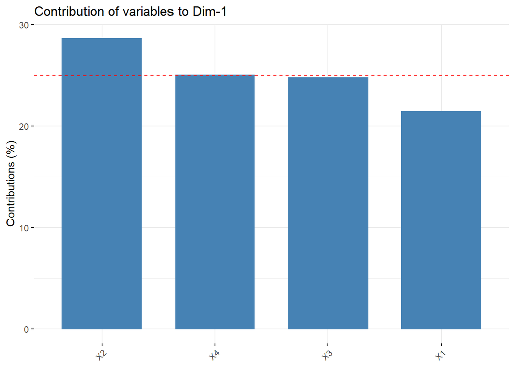

* RECOMMENDATION : : PCA1: X2 and X4 ( X4 very close to X3)

## FINALIZING VARIABLE/MODEL selection

| VAR | PRESS | VIF | $R^{2}$(adj) | $R^{2}$(pred) |
| --- | --- | --- | --- | --- |
| X1+X2 | 93.8 | 1 | 97% | 96% |
| X2+X4 | 1461.8 | 18 | 61% | 46% |
| X4+X1 | 121.2 | 1 | 96% | 95% |
| X2+X3 | 701.7 | 1 | 81% | 74% |

- RECOMMENDATION :PRESS stat should be small ( so that R-sq(pred) is high) and VIF=1.
- We will go with Model 1 : X1+X2

## FINAL Model : X1 + X2 : Validation of Regression Assumptions

- Normality test
  - Shapiro-wilks Test - Distribution is Normal
- W = 0.90219, p-value = 0.1433
- Anderson-Darling test - Distribution is normal
- A = 0.61361, p-value = 0.08628
- Equal Variance Test
  - studentized Breusch-Pagan test
  - BP = 0.16688, df = 2, p-value = 0.9199

## FINAL Model : X1 + X2 : Validation of Regression Assumptions (contd..)

- Independence/Auto Correllation Test (Durbin-Watson (D-W) test )

| lag | Autocorrelation | D-W Statistic | p-value |
| --- | --- | --- | --- |
| 1 | -0.05450402 | 1.92164 | 0.892 |

- Linearity test
  - Box-Tidwell test (Y,X1)
  - MLE of lambda Score Statistic (z) Pr(>|z|)

  - ```
      0.23145             -0.7366   0.4614
    ```

  - Box-Tidwell test ( Y,X2)
  - MLE of lambda Score Statistic (z) Pr(>|z|)
  - -0.71695 -1.35 0.177